# LARSEN_Data_Analysis_Final

2026-04-28

####Final Project:####

For my final project I decided to learn a new R-Package, since that was one of the suggested options on the Canvas page. I’m in a lab with Dr. Carl Hjelmen here at UVU working on genome size estimations with Mayflies and Dragonflies.

As a major part of this lab work, I will be using the package “Phytools” and its dependencies. I decided that this project would be the perfect way to get more familiar with that package. I used the book, “Phylogenetic Comparative Methods in R” by Liam J. Revell and Luke J. Harmon (the creators of this package) in order to learn.

My original plan was to go chapter by chapter and do every exercise in the book. Unfortunately my life got rather messy this semester including a go-kart crash that resulted in a concussion and a regular car crash that caused a mild resurgence of that concussion. Averaged out, I did roughly 10 minutes of work on this project a day from the 10th of February until the 27th of April. Some days I did more, some days I was unable to do any. I was able to go through the first four chapters of the book and get the main content done. I decided to skip most of the practice questions at the end of the chapter in favor of getting further.

I will be going over the book further this summer, and plan to return to those practice questions.

Here I will provide a brief summary of each chapter’s contents, as well as one or two figures generated in each chapter. After going over each chapter’s contents, I will run similar analysis on my real world data set about drosophila genome sizes.

All work is done from the current working directory that contains all my files needed. I am working in Data_Course_LARSEN/Final for my case. You can move the files where you wish, as long as you work from that directory.

```r
library(phytools)
library(geiger)
library(nlme)
library(phangorn)

#In previous projects I have made variable lists at the beginning with what they mean.
#Here I will not be doing this, as there's far too many to reasonably list here.
```

####Chapter 1####

Chapter 1 of the book offered an introduction to phylogenies and how to create and load them into R for analysis. We first practiced by generating a toy tree of vertebrates and then learning to attach numbers to each node. It also went over how to directly read in a tree to our environment using the read.tree function. I’ve had a very rough semester, so forgive me if we went over this in class and I have forgotten it. Much of February is a blur and I do not remember many events.

After learning to read in/generate a tree, I was walked through how one might cut and trim a phylogeny so that it matches with your .csv or other data file. This will be especially helpful for my current lab work since I will be working with real data that isn’t always clean. I will be using this technique on the drosophila data later.

We also worked briefly with a very simple PCA overview that will become more expanded upon in later chapters.

For Chapter 1 I have chosen to provide the initial vertebrate toy tree we made, a fan style tree with the clade we wanted to prune highlighted, and the practice question 1’s result (since this is the only practice problem I ended up doing)

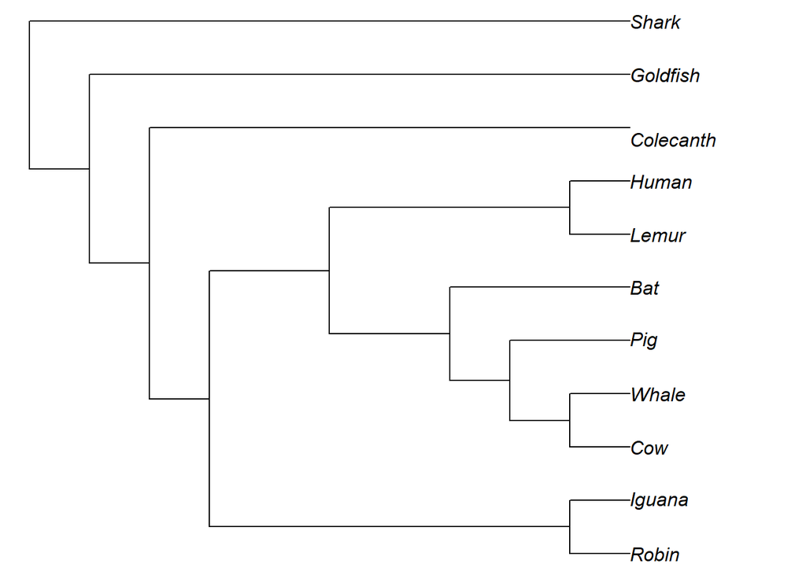

```r
#Here is our Toy Tree of Vertebrates
text.string <- "(((((Robin,Iguana),((((Cow,Whale), Pig),Bat),(Lemur, Human))),
Colecanth), Goldfish), Shark);"
vert.tree<-read.tree(text=text.string)
plot(vert.tree, no.margin = TRUE)
```

```r
##Here is the fan-style phylogeny
anolis.tree<-read.tree(file="Anolis.tre")
#We're going to learn how to use grep to help us subset and trim the tree
pr.species<-c("cooki", "poncensis", "gundlachi","pulchellus","stratulus","krugi","evermanni"
              , "occultus","cuvieri","cristatellus")
nodes<-sapply(pr.species, grep, x=anolis.tree$tip.label)
nodes
```

```
##        cooki    poncensis    gundlachi   pulchellus    stratulus        krugi
##           26           25           24           23           21           22
##    evermanni     occultus      cuvieri cristatellus
##           20          100           54           27
```

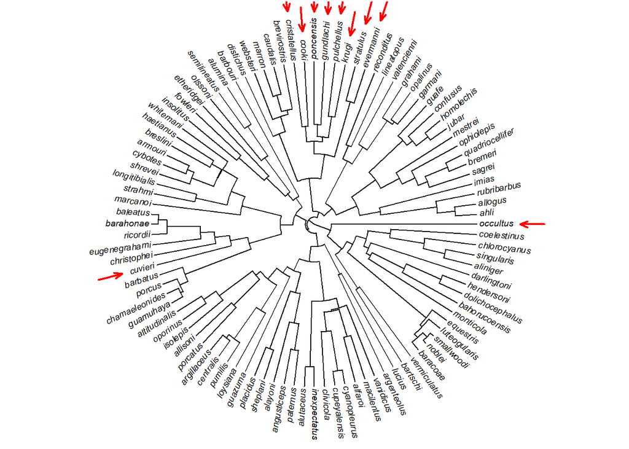

```r
#sapply made it so I didn't need to write a loop for this
#ie, what we did here was: "apply to the elements of pr.species the function grep with the argument x of grep set to anolis.tree$tip.label"
plotTree(anolis.tree, type="fan", fsize=0.6, lwd=1, ftype="i")
add.arrow(anolis.tree, tip = nodes, arrl=0.15, col="red", offset=2)
```

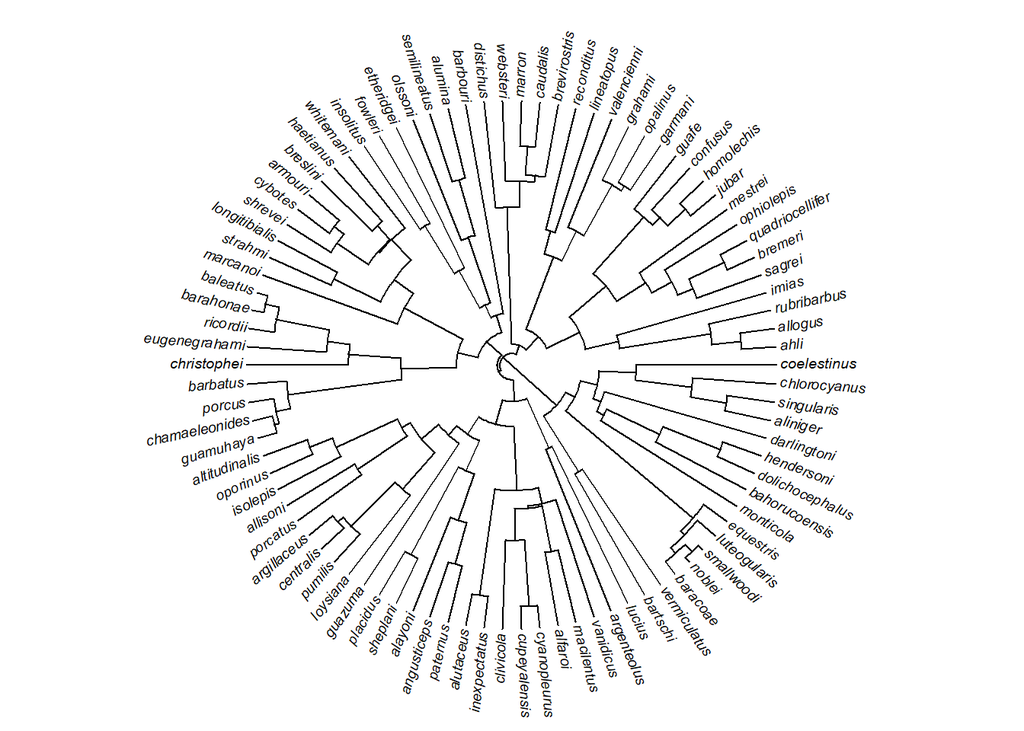

```r
anolis.noPR<-drop.tip(anolis.tree, pr.species)
plotTree(anolis.noPR, type="fan", fsize=0.6, lwd=1, ftype="i")
```

```r
#Now we're extracting a clade, rather than dropping it.

node<-getMRCA(anolis.tree, pr.species[-which(pr.species%in%c("cuvieri","occultus"))])
node
```

```
## [1] 123
```

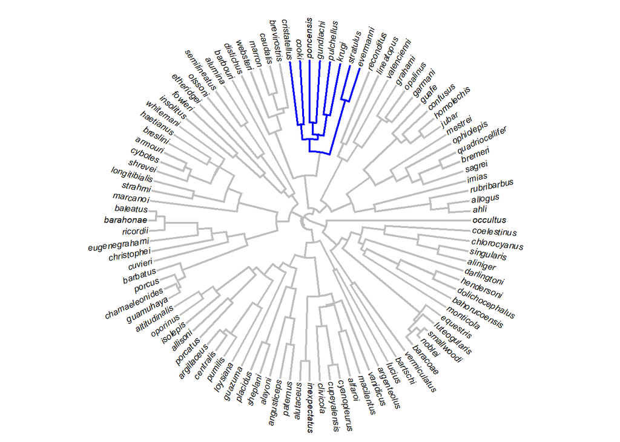

```r
#we're getting fancy with it now
plot(paintSubTree(anolis.tree, node, "b","a"), type="fan", fsize=0.6, lwd=2,
     colors=setNames(c("gray","blue"), c("a","b")), ftype="i")
```

```r
##And here is the practice problem's result:
pheldat<-read.csv("phel.csv", row.names = 1, header = TRUE, stringsAsFactors = TRUE)
pheltree<-read.tree(file="phel.phy")
name.check(pheltree, pheldat)
```

```
## $tree_not_data
##  [1] "andamanense"       "anjouanensis"      "cepedianaB"
##  [4] "comoraegrandensis" "edwardnewtoni"     "gigas"
##  [7] "inexpectata"       "kochi"             "leiogaster"
## [10] "parkeri"           "pasteuri"          "rosagularis"
## [13] "serraticauda"      "vnigra"
##
## $data_not_tree
## [1] "cepedianaA"
```

```r
chk2<-name.check(pheltree, pheldat)
length(intersect(pheltree$tip.label, rownames(pheldat)))
```

```
## [1] 19
```

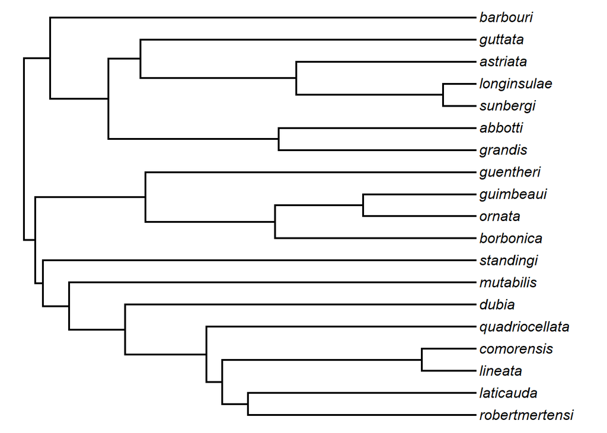

```r
pheltreeprun <- drop.tip(pheltree, chk2$tree_not_data)
plotTree(pheltreeprun, ftype="i", cex=1.1)
```

####Chapter 2 ####

This was the chapter where I realized that I had very possibly made a mistake and probably should not be doing this project without taking another stat’s class first. I read Felsenstein in my Principles of Evolution class this semester and I do not like the man’s style. He explains math in a way that is quite confusing to me. It is no coincidence that this chapter is where I struggled the most in terms of understanding.

After creating a chart which I have no real comprehension of (which I will nonetheless provide here) we go over some linear models in R. We ended up using some of these in class, which I believe did help me somewhat to understand them further.

I don’t recall us in class discussing OLS model though. We went over this model and how to use it in specific circumstances. OLS stands for Ordinary Least Squares. You don’t get a whole lot by just outputting the OLS, you generally have to put it on top of other data.

We used a seed to generate a tree that helped demonstrate that this type of model is quite easy to fall into a type I error with. I will skip most of this chapter as a result in my report, and only include the nasty chart I didn’t understand, and the type I error example (and how we corrected it)

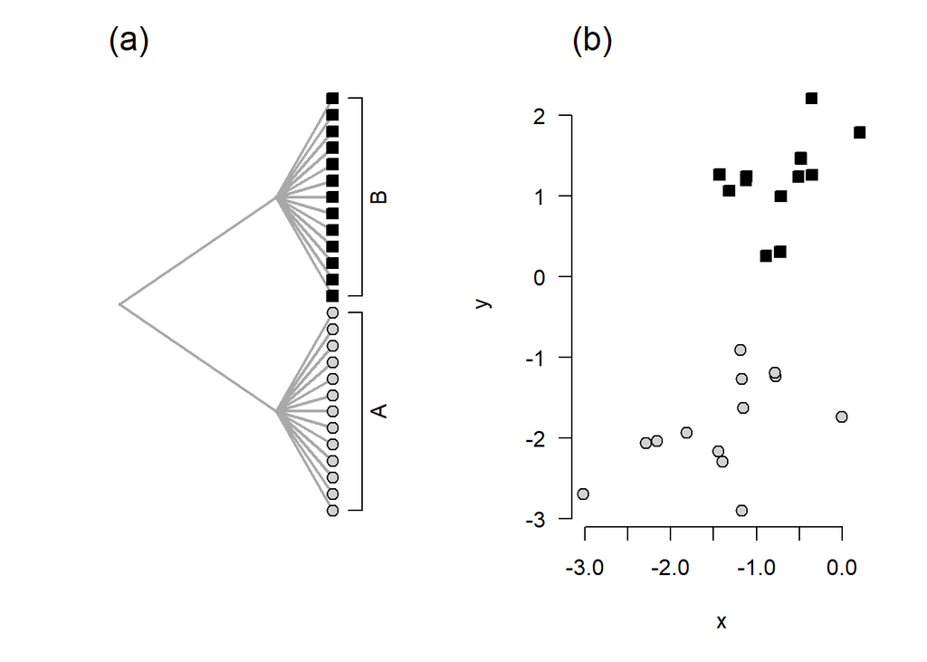

```r
###Here's the real funky plot from the beginning of the chapter I didn't really understand
tree<-read.tree(text="((A,B,C,D,E,F,G,H,I,J,K,L,M),(N,O,P,Q,R,S,T,U,V,W,X,Y,Z));")
##Set branch lengths on the tree
tree<-compute.brlen(tree, power=1.8)
##simmulate data, idependently for x and y
x<-fastBM(tree)
y<-fastBM(tree)
## Plot the results iwth clades A and B labled.
##split the plotting area
par(mfrow=c(1,2))
#graphing the tree
plotTree(tree, type="cladogram", ftype="off", mar=c(5.1,4.1,3.1,2.1), color="darkgray",
         xlim=c(0,1.3), ylim=c(1,Ntip(tree)))
##add pointsa t the tips of the tree to match those on our scatterplot.
points(rep(1,13), 1:13, pch=21, bg="lightgray", cex=1.2)
points(rep(1,13), 14:26, pch=22, bg="black", cex=1.2)
##add clade labels to the treec
cladelabels(tree, "A", node=28, offset=2)
cladelabels(tree, "B", node=29, offset=2)
mtext("(a)", line=1, adj=0, cex=1.5)
##mking the scatter plot of the x and y
par(mar=c(5.1,4.1,3.1,2.1))
plot(x,y,bty="n",las=1)
points(x[1:13],y[1:13],pch=21, bg="lightgray", cex=1.2)
points(x[14:26],y[14:26],pch=22, bg="black", cex=1.2)
mtext("(b)", line=1, adj=0, cex=1.5)
```

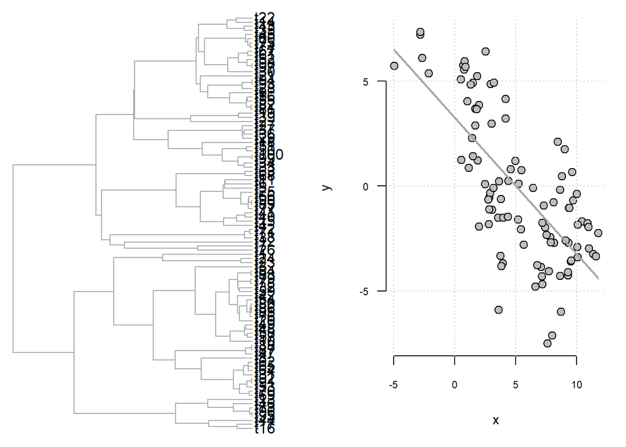

```r
###Here's the example we used to generate and then correct type 1 error
set.seed(1001)

##making a complicated tree from the book
##set starting tree to NULL
tree<-NULL
##repeat simulation until non-NULL (ie, non extinct) tree is obatined.
while(is.null(tree))
  tree<-pbtree(n=100,b=1,d=0.8,extant.only=TRUE)
##plot the simulated tree
plotTree(tree,fytpe="off",color="darkgray",lwd=1)

#simulating evolution on the tree.
x<-fastBM(tree)
y<-fastBM(tree)
par(mar=c(5.1,4.1,1.1,1.1))
plot(x,y,cex=1.2,pch=21,bg="gray",las=1,cex.axis=0.7, cex.lab=0.9,bty="n")
grid()
clip(min(x),max(x),min(y),max(y))
fit.ols<-lm(y~x)
abline(fit.ols,lwd=2,col="darkgray")
```

```r
fit.ols
```

```
##
## Call:
## lm(formula = y ~ x)
##
## Coefficients:
## (Intercept)            x
##       3.253       -0.649
```

```r
summary(fit.ols)
```

```
##
## Call:
## lm(formula = y ~ x)
##
## Residuals:
##     Min      1Q  Median      3Q     Max
## -6.8190 -1.7275  0.0882  1.9320  4.8112
##
## Coefficients:
##             Estimate Std. Error t value Pr(>|t|)
## (Intercept)   3.2529     0.4246   7.662 1.33e-11 ***
## x            -0.6490     0.0653  -9.939  < 2e-16 ***
## ---
## Signif. codes:  0 '***' 0.001 '**' 0.01 '*' 0.05 '.' 0.1 ' ' 1
##
## Residual standard error: 2.477 on 98 degrees of freedom
## Multiple R-squared:  0.502,  Adjusted R-squared:  0.4969
## F-statistic: 98.79 on 1 and 98 DF,  p-value: < 2.2e-16
```

```r
#This example shows that it's not difficult at all for the phylogeny to generate a Type I Error
#Now we're going to try to resolve the Type I Error
##Compute PICs for x and y
ix<-pic(x,tree)
iy<-pic(y,tree)
##Fit PIC regression through the origin
fit.pic<-lm(iy~ix+0)
fit.pic
```

```
##
## Call:
## lm(formula = iy ~ ix + 0)
##
## Coefficients:
##       ix
## -0.07094
```

```r
##setting plotting margins
par(mar=c(5.1,4.1,1.1,1.1))
##graphing it
plot(ix,iy,cex=1.2,pch=21,bg="gray",las=1,xlab="PICs for x", ylab="PICs for y",
     cex.axis=0.7,cex.lab=0.9,bty="n")
grid()
clip(min(ix),max(ix),min(iy),max(iy))
abline(fit.pic,lwd=2,col="darkgray")
summary(fit.pic)
```

```
##
## Call:
## lm(formula = iy ~ ix + 0)
##
## Residuals:
##     Min      1Q  Median      3Q     Max
## -2.4538 -0.6708 -0.1080  0.6791  2.4256
##
## Coefficients:
##    Estimate Std. Error t value Pr(>|t|)
## ix -0.07094    0.12032   -0.59    0.557
##
## Residual standard error: 1.049 on 98 degrees of freedom
## Multiple R-squared:  0.003534,   Adjusted R-squared:  -0.006634
## F-statistic: 0.3476 on 1 and 98 DF,  p-value: 0.5568
```

```r
#Now the statistical significance has disappeared
```

[figure not shown]

####Chapter 3####

Chapter 3 was also about linear models. This time we were introduced to the PGLS. This one stands for Phylogenetic Generalized Least Squares, and also doesn’t sound like the Swedish word for beer (öl), which is kind of less fun. Even if I didn’t fully understand how OLS worked.

I learned how to convert a tree to a correlation structure using functions from ape. After learning to do this, we compared PICS and PGLS. I’m uncertain as to what exactly a PIC is, but it was used a lot. I think this is just me forgetting. The chapter also gives a preview of Pagal’s Lambda which we use more in Chapter 4. We finish the chapter off with learning how to apply these models to an ANOVA table, or more specifically an ANCOVA one.

I will provide the data extraction and the comparison between PGLS and PICs for this chapter, as well as the ACNOVA section and the plot we made at the end to illustrate these differences. Data for this chapter was related to primate eyes.

```r
###Getting the data from the trees
primate.data<-read.csv("primateEyes.csv", row.names = 1, stringsAsFactors = TRUE)
primate.tree<-read.tree("primateEyes.phy")
orbit.area<-setNames(primate.data[,"Orbit_area"], rownames(primate.data))
skull.length<-setNames(primate.data[,"Skull_length"], rownames(primate.data))
##Now we're computing PICs on the log-transformed values of both traits
pic.orbit.area<-pic(log(orbit.area),primate.tree)
pic.skull.length<-pic(log(skull.length), primate.tree)
##Fitting a linear regrression to the orbit as a function of skull.
pic.primate<-lm(pic.orbit.area~pic.skull.length+0)
summary(pic.primate)
```

```
##
## Call:
## lm(formula = pic.orbit.area ~ pic.skull.length + 0)
##
## Residuals:
##       Min        1Q    Median        3Q       Max
## -0.103535 -0.023104 -0.004624  0.021021  0.175298
##
## Coefficients:
##                  Estimate Std. Error t value Pr(>|t|)
## pic.skull.length  1.37867    0.07734   17.83   <2e-16 ***
## ---
## Signif. codes:  0 '***' 0.001 '**' 0.01 '*' 0.05 '.' 0.1 ' ' 1
##
## Residual standard error: 0.03738 on 88 degrees of freedom
## Multiple R-squared:  0.7831, Adjusted R-squared:  0.7807
## F-statistic: 317.8 on 1 and 88 DF,  p-value: < 2.2e-16
```

```r
## This gives us a highly significant slope.

###Comparing the PICS and PGLS
#Converting our tree to a correlation structure so we can use the GLS on it
#apparently we're using the ape function "corBrownian"
spp<-rownames(primate.data)
corBM<-corBrownian(phy=primate.tree, form=~spp)
corBM
```

```
## Uninitialized correlation structure of class corBrownian
```

```r
#the spp thing was to specify the order of the taxa in our data.
pgls.primate<-gls(log(Orbit_area)~log(Skull_length), data=primate.data, correlation=corBM)
#it doesn't seem that differnt from what we were doing last chapter.
#the correlation variable is set to the corBM which we made earlier.
#It's our corStruct object we made.
summary(pgls.primate)
```

```
## Generalized least squares fit by REML
##   Model: log(Orbit_area) ~ log(Skull_length)
##   Data: primate.data
##         AIC       BIC   logLik
##   -79.58758 -72.15557 42.79379
##
## Correlation Structure: corBrownian
##  Formula: ~spp
##  Parameter estimate(s):
## numeric(0)
##
## Coefficients:
##                        Value Std.Error   t-value p-value
## (Intercept)       -0.2018553 0.3499265 -0.576851  0.5655
## log(Skull_length)  1.3786743 0.0773418 17.825741  0.0000
##
##  Correlation:
##                   (Intr)
## log(Skull_length) -0.923
##
## Standardized residuals:
##        Min         Q1        Med         Q3        Max
## -2.5903639 -1.0543078 -0.7395119 -0.2535879  2.4063079
##
## Residual standard error: 0.3193421
## Degrees of freedom: 90 total; 88 residual
```

```r
#Comparing PICs and PGLS
coef(pic.primate)
```

```
## pic.skull.length
##         1.378674
```

```r
coef(pgls.primate)
```

```
##       (Intercept) log(Skull_length)
##        -0.2018553         1.3786743
```

```r
abs(coef(pic.primate)[1]-coef(pgls.primate)[2])
```

```
## pic.skull.length
##     6.479262e-12
```

```r
#Because our absolute value returned is very very small, we can conclude that the
#methods have returned the same estimated model slopes
#We can also compare our p-values directly
summary(pic.primate)$coefficients[1,4]
```

```
## [1] 5.939575e-31
```

```r
summary(pgls.primate)$tTable[2,4]
```

```
## [1] 5.939575e-31
```

```r
#To at least 7 digits of precision, our models match perfectly

###The ACNOVA table
primate.ancova<-gls(log(Orbit_area)~log(Skull_length)+ Activity_pattern, data=primate.data,
                    correlation = corBM)
anova(primate.ancova)
```

```
## Denom. DF: 86
##                   numDF   F-value p-value
## (Intercept)           1 2017.1877  <.0001
## log(Skull_length)     1  376.6683  <.0001
## Activity_pattern      2    9.1575   2e-04
```

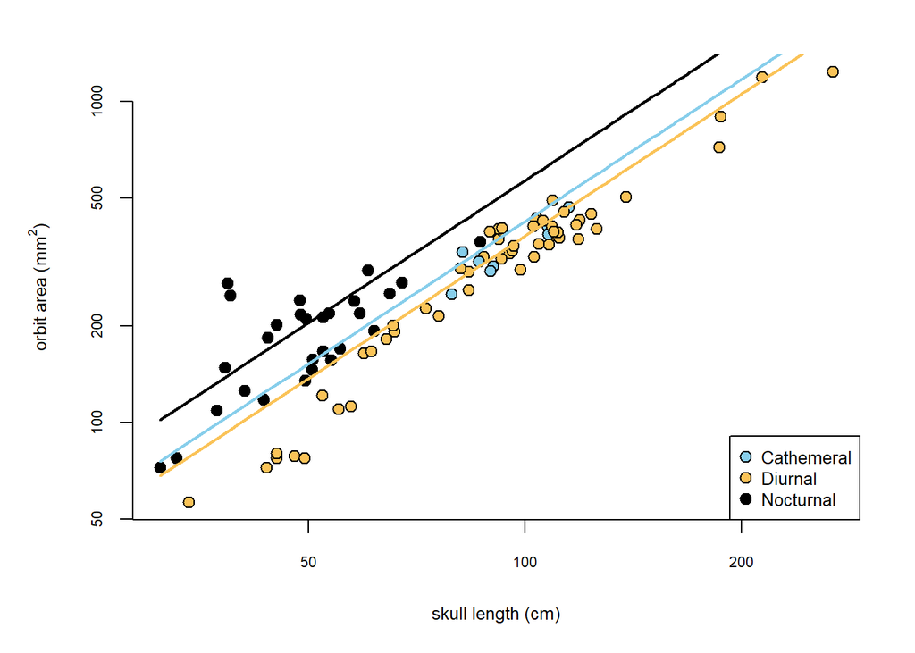

```r
###And finally the plot we made at the end to see this pattern.
par(mfrow=c(1,1),mar=c(5.1,5.1,2.1,2.1))
##setting the point colors for the different levels of our factor
pt.cols<-setNames(c("#87CEEB","#FAC358","black"),levels(primate.data$Activity_pattern))
plot(Orbit_area~Skull_length, data=primate.data,pch=21,
     bg=pt.cols[primate.data$Activity_pattern],log="xy",bty="n",
     xlab="skull length (cm)", ylab=expression(paste("orbit area (",mm^2,")")),
     cex=1.2,cex.axis=0.7,cex.lab=0.8)
##adding a legend
legend("bottomright",names(pt.cols),pch=21,pt.cex=1.2,pt.bg=pt.cols,cex=0.8)
##create a common set of x values to plot our different lines for each level of
##the factor
xx<-seq(min(primate.data$Skull_length),max(primate.data$Skull_length),length.out=100)
##add lines for each level of the factor
lines(xx,exp(predict(primate.ancova, newdata=data.frame(Skull_length=xx,
                                                        Activity_pattern=as.factor(rep("Cathemeral",100))))),
      lwd=2,col=pt.cols["Cathemeral"])
lines(xx,exp(predict(primate.ancova, newdata = data.frame(Skull_length=xx,
                                                          Activity_pattern=as.factor(rep("Diurnal",100))))),
      lwd=2,col=pt.cols["Diurnal"])
lines(xx,exp(predict(primate.ancova, newdata = data.frame(Skull_length=xx,
                                                          Activity_pattern=as.factor(rep("Nocturnal",100))))),
      lwd=2,col=pt.cols["Nocturnal"])
```

####Chapter 4####

In my head, I kept calling this chapter the Drunkard’s Walk chapter. This is because my lab mentor explained Brownian Motion to me as a drunkard stumbling around between a wall and a train track. He’s going weird directions with each step, and on one side there’s a wall that stops him from going any further. On the other side there’s a train track that will kill him if he falls into it. Things are evolving kinda randomly and they can either reach a point where they fix a trait or otherwise go no further, or kill themselves off.

This is the chapter where we went into BM as well as other models like EB and briefly OU.It’s also the chapter where I realized that I REALLY needed to have taken more stats classes before I picked up this book. I understand about a third of the math stuff here.

I’m also fairly certain the book got part of itself wrong, referring to the graph as a “Left Skewed Test” when it was a Right Skewed Test. Perhaps it means something different here, but I was taught in my stat’s class I have taken that the more extreme values are the ones that determine the skewness of the graph. Longer tail, that’s the side it’s skewed to.

We went over Bloomberg’s K and Pagel’s Lambda a bit more. The K value is for when the evolutionary movement is larger than expected and Lambda is for smaller values. That’s what I ended up gathering from the chapter. And from the sound of it, that’s all I needed to know for the sake of this chapter. It will tell me more nuance later in the book over the summer.

I’ve provided the first BM plot the book guided me to make, the bacteria data that was used, the K and Lambda first problems, and the end comparison between all three models. (With some odd variable names because I was getting sick of dots and underscores and found using character names was easier on me.)

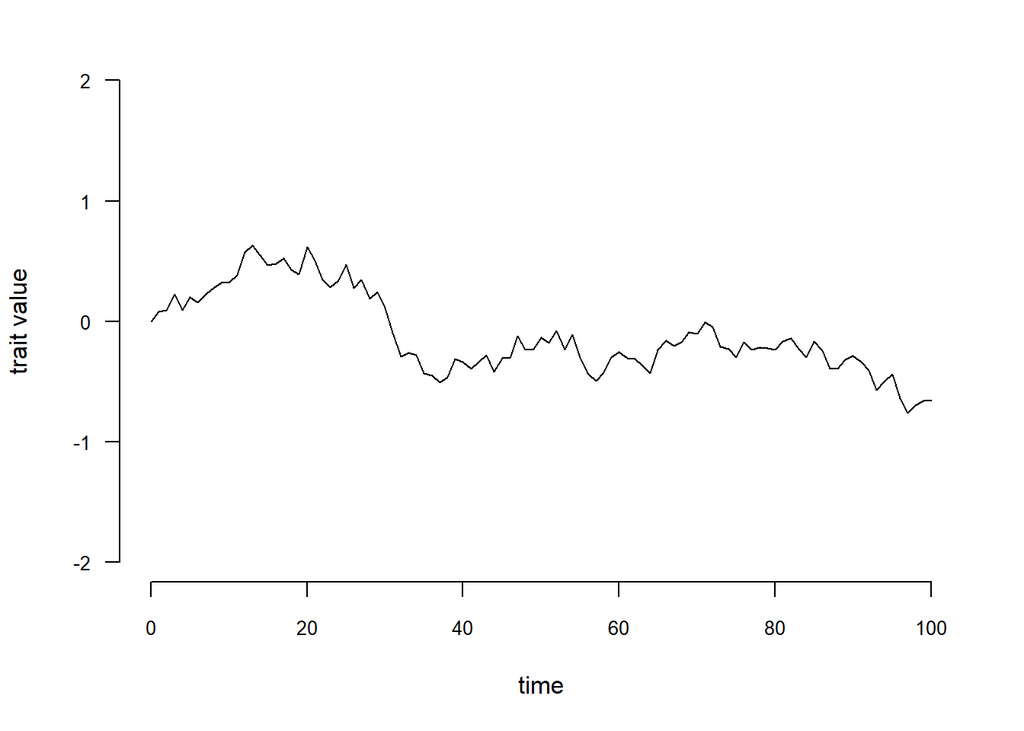

```r
##First BM Plot we made for the book
##set values for the time steps and sigma squared parameter
t<-0:100
sig2<-0.01
##simulate a set of random changes
x<-rnorm(n=length(t)-1,sd=sqrt(sig2))
##compute their cummulative sum.
x<-c(0,cumsum(x))
##create a plot with nice margins
par(mar=c(5.1,4.1,2.1,2.1))
plot(t,x,type="l",ylim=c(-2,2),bty="n",xlab="time",ylab="trait value",las=1,cex.axis=0.8)
```

```r
bacteria.data<-read.csv("bac_rates.csv",row.names = 1)
head(bacteria.data)
```

```
##                         Accumulation_Rate Genome_Size_Mb GC_Content_Percent
## Acinetobacter_baumannii          1.99e-06      4.0369921           39.02430
## Bordetella_pertussis             2.24e-07      4.1151522           67.70278
## Buchnera_aphidicola              1.10e-07      0.5915785           25.18965
## Burkholderia_dolosa              3.28e-07      6.4090900           67.03530
## Campylobacter_jejuni             3.23e-05      1.6767532           30.40345
## Chlamydophila_psittaci           1.74e-05      1.1698112           39.03149
##                         Lab_Doubline_Time_Hours    piN.piS
## Acinetobacter_baumannii                      NA 0.04851772
## Bordetella_pertussis                        3.8 0.46038453
## Buchnera_aphidicola                          NA 0.05394829
## Burkholderia_dolosa                         1.7         NA
## Campylobacter_jejuni                        1.5 0.08549450
## Chlamydophila_psittaci                      2.0 0.16313184
```

```r
bacteria.tree<-read.tree("bac_rates.phy")
print(bacteria.tree,printlen=2)
```

```
##
## Phylogenetic tree with 34 tips and 33 internal nodes.
##
## Tip labels:
##   Mycoplasma_gallisepticum, Mycobacterium_tuberculosis, ...
##
## Rooted; includes branch length(s).
```

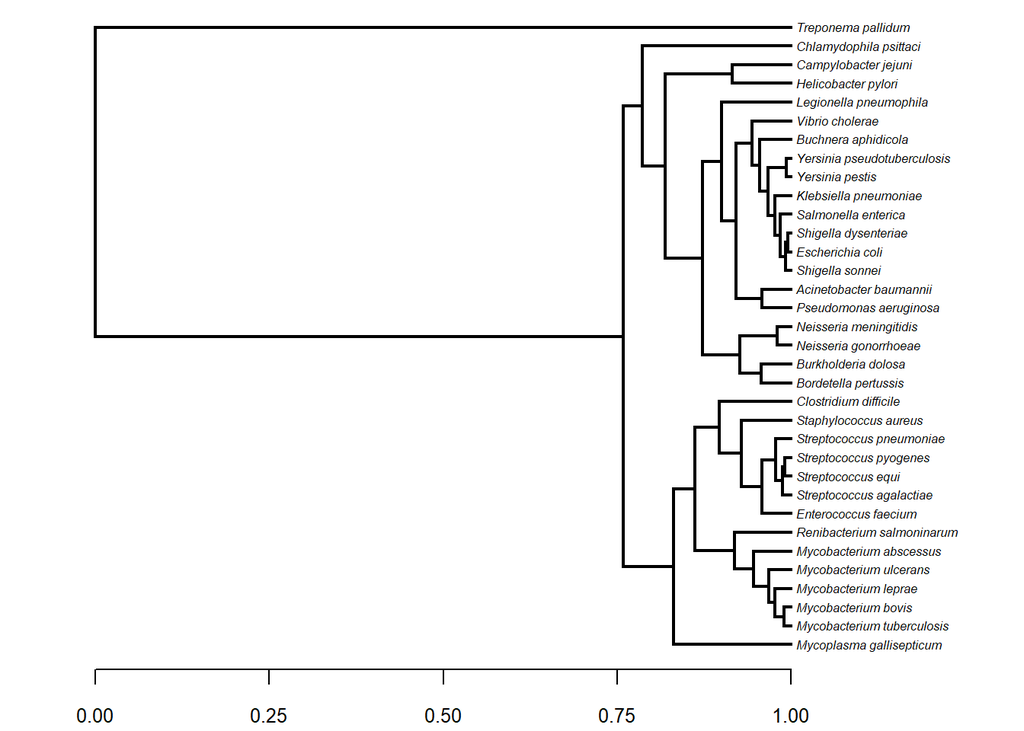

```r
plotTree(bacteria.tree, ftype="i",fsize=0.5,ldw=1,mar=c(2.1,2.1,0.1,1.1))
axis(1,at=seq(0,1,length.out=5),cex.axis=0.8)
```

```r
library(geiger)
name.check(bacteria.tree,bacteria.data)
```

```
## [1] "OK"
```

```r
genome_size<-bacteria.data[,"Genome_Size_Mb"]
genome_size
```

```
##  [1] 4.0369921 4.1151522 0.5915785 6.4090900 1.6767532 1.1698112 4.2182558
##  [8] 3.0148471 5.0945238 1.6251464 5.6341215 3.4300281 5.0295090 4.3600613
## [15] 3.2681350 4.4043280 5.8057600 0.9699609 2.2106470 2.1890708 6.6193001
## [22] 3.1552500 4.8180117 4.5205550 5.0991850 2.8536100 2.0675049 2.1404940
## [29] 2.1154909 1.8365169 1.1386050 4.1043307 4.7494239 4.7837531
```

```r
#oopsies, now our vector doesn't have names, just the numbers.
#Let's fix that.
names(genome_size)<-rownames(bacteria.data)
head(genome_size)
```

```
## Acinetobacter_baumannii    Bordetella_pertussis     Buchnera_aphidicola
##               4.0369921               4.1151522               0.5915785
##     Burkholderia_dolosa    Campylobacter_jejuni  Chlamydophila_psittaci
##               6.4090900               1.6767532               1.1698112
```

```r
#Now we can fit the BM to our data.

#We're using Geiger's function of fitContinuous, which uses GM as the default
fitBM_gs<-fitContinuous(bacteria.tree,genome_size)
fitBM_gs
```

```
## GEIGER-fitted comparative model of continuous data
##  fitted 'BM' model parameters:
##  sigsq = 24.990480
##  z0 = 1.984134
##
##  model summary:
##  log-likelihood = -59.279289
##  AIC = 122.558578
##  AICc = 122.945675
##  free parameters = 2
##
## Convergence diagnostics:
##  optimization iterations = 100
##  failed iterations = 0
##  number of iterations with same best fit = 100
##  frequency of best fit = 1.000
##
##  object summary:
##  'lik' -- likelihood function
##  'bnd' -- bounds for likelihood search
##  'res' -- optimization iteration summary
##  'opt' -- maximum likelihood parameter estimates
```

```r
mutation<-setNames(bacteria.data[,"Accumulation_Rate"],rownames(bacteria.data))
head(mutation)
```

```
## Acinetobacter_baumannii    Bordetella_pertussis     Buchnera_aphidicola
##                1.99e-06                2.24e-07                1.10e-07
##     Burkholderia_dolosa    Campylobacter_jejuni  Chlamydophila_psittaci
##                3.28e-07                3.23e-05                1.74e-05
```

```r
ln_mutation<-log(mutation)
fitBM_ar<-fitContinuous(bacteria.tree,ln_mutation)
fitBM_ar
```

```
## GEIGER-fitted comparative model of continuous data
##  fitted 'BM' model parameters:
##  sigsq = 65.935009
##  z0 = -13.720388
##
##  model summary:
##  log-likelihood = -75.772258
##  AIC = 155.544515
##  AICc = 155.931612
##  free parameters = 2
##
## Convergence diagnostics:
##  optimization iterations = 100
##  failed iterations = 0
##  number of iterations with same best fit = 100
##  frequency of best fit = 1.000
##
##  object summary:
##  'lik' -- likelihood function
##  'bnd' -- bounds for likelihood search
##  'res' -- optimization iteration summary
##  'opt' -- maximum likelihood parameter estimates
```

```r
###K value, which this function defaults to
phylosig(bacteria.tree, genome_size)
```

```
##
## Phylogenetic signal K : 0.349525
```

```r
K_gs<-phylosig(bacteria.tree,genome_size, test=TRUE, nsim=10000)
K_gs
```

```
##
## Phylogenetic signal K : 0.349525
## P-value (based on 10000 randomizations) : 1e-04
```

```r
K_ar<-phylosig(bacteria.tree,ln_mutation,test=TRUE,nsim=10000)
K_ar
```

```
##
## Phylogenetic signal K : 0.105888
## P-value (based on 10000 randomizations) : 0.0822
```

```r
###And now for Lambda (Which we do have to specify)
phylosig(bacteria.tree,genome_size,method="lambda")
```

```
##
## Phylogenetic signal lambda : 1.00173
## logL(lambda) : -59.1365
```

```r
phylosig(bacteria.tree,ln_mutation,method="lambda")
```

```
##
## Phylogenetic signal lambda : 0.923686
## logL(lambda) : -64.5216
```

```r
lambda_gs<-phylosig(bacteria.tree,genome_size,method="lambda",test=TRUE)
lambda_gs
```

```
##
## Phylogenetic signal lambda : 1.00173
## logL(lambda) : -59.1365
## LR(lambda=0) : 11.3482
## P-value (based on LR test) : 0.00075521
```

```r
lambda_ar<-phylosig(bacteria.tree,ln_mutation,method="lambda",test=TRUE)
lambda_ar
```

```
##
## Phylogenetic signal lambda : 0.923686
## logL(lambda) : -64.5216
## LR(lambda=0) : 6.55541
## P-value (based on LR test) : 0.0104566
```

```r
###fit EB model to genome size
#Back to the awful variabe names
#Alright, I'm sick of _ and . and wahtever.
#The fitEB_gs from the book is now Barda
Barda<-fitContinuous(bacteria.tree,genome_size,model="EB")
Barda
```

```
## GEIGER-fitted comparative model of continuous data
##  fitted 'EB' model parameters:
##  a = -0.000001
##  sigsq = 24.990505
##  z0 = 1.984134
##
##  model summary:
##  log-likelihood = -59.279290
##  AIC = 124.558580
##  AICc = 125.358580
##  free parameters = 3
##
## Convergence diagnostics:
##  optimization iterations = 100
##  failed iterations = 0
##  number of iterations with same best fit = 9
##  frequency of best fit = 0.090
##
##  object summary:
##  'lik' -- likelihood function
##  'bnd' -- bounds for likelihood search
##  'res' -- optimization iteration summary
##  'opt' -- maximum likelihood parameter estimates
```

```r
#So, the book is saying that I should've gotten an error, but I didn't.
#Maybe that was fixed in an update to R Studio.
#I'm getting the same vablues otherwise
#like a being really relaly close to zero.

#fitOU_gs is going to be called Lief
Lief<-fitContinuous(bacteria.tree,genome_size,model="OU")
#This time I did get the error message, interesting.
Lief
```

```
## GEIGER-fitted comparative model of continuous data
##  fitted 'OU' model parameters:
##  alpha = 2.718282
##  sigsq = 30.119232
##  z0 = 2.331269
##
##  model summary:
##  log-likelihood = -57.129984
##  AIC = 120.259969
##  AICc = 121.059969
##  free parameters = 3
##
## Convergence diagnostics:
##  optimization iterations = 100
##  failed iterations = 0
##  number of iterations with same best fit = 34
##  frequency of best fit = 0.340
##
##  object summary:
##  'lik' -- likelihood function
##  'bnd' -- bounds for likelihood search
##  'res' -- optimization iteration summary
##  'opt' -- maximum likelihood parameter estimates
```

```r
#Apparently this error this time indicates that our Lief thing is at the upper bounds of
#the default optimization
#So we change them.
Lief<-fitContinuous(bacteria.tree,genome_size,model="OU",bounds=list(alpha=c(0,10)))
Lief
```

```
## GEIGER-fitted comparative model of continuous data
##  fitted 'OU' model parameters:
##  alpha = 6.871261
##  sigsq = 40.534696
##  z0 = 2.750270
##
##  model summary:
##  log-likelihood = -56.380463
##  AIC = 118.760925
##  AICc = 119.560925
##  free parameters = 3
##
## Convergence diagnostics:
##  optimization iterations = 100
##  failed iterations = 0
##  number of iterations with same best fit = 47
##  frequency of best fit = 0.470
##
##  object summary:
##  'lik' -- likelihood function
##  'bnd' -- bounds for likelihood search
##  'res' -- optimization iteration summary
##  'opt' -- maximum likelihood parameter estimates
```

```r
#Ther's no warning now, and both are optimized alpha value and our log liklihood are higher
#I think that makes sense, but I'm not sure.
#I think it's unfare of the book to just throw that towards us
#when we haven't talked about OU yet
#I don't know what this means yet

#COmpare the EB and OU, and BM, we can just use an information criterion like the AIC
##accumulate AIC scores from our three models into a vector
#Gonna call this one Jasmine
Jasmine<-setNames(c(AIC(fitBM_gs),AIC(Barda),AIC(Lief)),c("BM","EB","OU"))
Jasmine
```

```
##       BM       EB       OU
## 122.5586 124.5586 118.7609
```

```r
#Here we want the LOWEST AIC score.
#In this case, that's OU, or Lief.
```

For the sake of this class and letting myself do this write up, I ran out of time. I spent a good 10 hours on this broken up over the semester, so I do not feel like I wasted my time. I’ll be pushing the full practice script with this R Markdown, so you can see that I actually did work there too and didn’t just pick and choose randomly from the book.

####Drosophila Data Set####

Now I am going to attempt to apply what I have learned to my drosophilia data set that Dr. Hjelmen gave to me. Get ready for me to make a fool of myself and you can go laugh at me with him.

I will be making a phylogeny plot, getting the BM, EB, and OU models up for genome size, and then comparing the three models. I will be skipping most of chapters 2 and 3 because I don’t know how to interpret them, so I feel unable to properly tun their code. However, I am still glad I went through them because I feel they have helped me understand more in general.

I guess let’s start by loading in the information.

```r
alldat<-read.csv("alldata.csv")
mtree<-read.tree("male.tree.tre")
ftree<-read.tree("female.tree.tre")
ddtree<-read.nexus("dateddrostree.nex")
```

Now that we have these files loaded in, let’s make our tree, we’re just doing one here for sake of time. I have a court case later today for that car crash mentioned and I need to get this done now so I can submit it on time.

We’re using the female tree because I can’t get the ddtree to work. Sorry.

```r
rownames(alldat) <- alldat$Species
fchk<-name.check(ftree, alldat)
head(alldat)
```

```
##                                     Species NewChrom ChromArm MbDNA_Female
## Chymomyza_amoena           Chymomyza_amoena        4        6        395.2
## Chymomyza_procnemis     Chymomyza_procnemis        4        6        298.2
## Drosophila_arizonae     Drosophila_arizonae       NA       NA        175.4
## Drosophila_mojavensis Drosophila_mojavensis        6        6        165.6
## Drosophila_mayaguana   Drosophila_mayaguana       NA       NA        170.0
## Drosophila_navojoa       Drosophila_navojoa       NA       NA        170.0
##                       Female_UR Female_Rep Female_Unrep MbDNA_Male Male_UR
## Chymomyza_amoena             NA         NA           NA      384.8      NA
## Chymomyza_procnemis          NA         NA           NA      262.4      NA
## Drosophila_arizonae       0.962      168.7          6.7      173.9      NA
## Drosophila_mojavensis     0.965      159.8          5.8      168.7      NA
## Drosophila_mayaguana      0.987      167.8          2.2      161.7   0.945
## Drosophila_navojoa        0.964      163.9          6.1      156.2   0.963
##                       Male_Rep Male_Unrep SexDiff SexDiffRep SexDiffUnrep
## Chymomyza_amoena            NA         NA    20.8         NA           NA
## Chymomyza_procnemis         NA         NA    71.6         NA           NA
## Drosophila_arizonae         NA         NA     3.0         NA           NA
## Drosophila_mojavensis       NA         NA    -6.1         NA           NA
## Drosophila_mayaguana     152.8        8.9    16.6       30.0     -13.3670
## Drosophila_navojoa       150.4        5.8    27.6       26.9       0.6812
##                       Chromosomes     Groups Sex.System FemaleTree MaleTree
## Chymomyza_amoena                4   Outgroup         XY      Other    Other
## Chymomyza_procnemis             4   Outgroup         X0      Other    Other
## Drosophila_arizonae            NA Drosophila         XY     Female    Other
## Drosophila_mojavensis           6 Drosophila         XY     Female    Other
## Drosophila_mayaguana           NA Drosophila       <NA>     Female     Male
## Drosophila_navojoa             NA Drosophila       <NA>     Female     Male
##                            GroupFemale       GroupMale         Montium
## Chymomyza_amoena         OutgroupOther   OutgroupOther           Other
## Chymomyza_procnemis      OutgroupOther   OutgroupOther           Other
## Drosophila_arizonae   DrosophilaFemale DrosophilaOther DrosophilaOther
## Drosophila_mojavensis DrosophilaFemale DrosophilaOther DrosophilaOther
## Drosophila_mayaguana  DrosophilaFemale  DrosophilaMale DrosophilaOther
## Drosophila_navojoa    DrosophilaFemale  DrosophilaMale DrosophilaOther
##                       Female.Chrom.Tree Female.Arm.Tree
## Chymomyza_amoena                  Other               6
## Chymomyza_procnemis               Other               6
## Drosophila_arizonae                <NA>              NA
## Drosophila_mojavensis                 6               6
## Drosophila_mayaguana               <NA>              NA
## Drosophila_navojoa                 <NA>              NA
```

```r
length(fchk$tree_not_data)
```

```
## [1] 0
```

```r
Ntip(ftree)
```

```
## [1] 132
```

```r
head(ftree$tip.label)
```

```
## [1] "Drosophila_pseudotalamancana" "Scaptomyza_anomala"
## [3] "Drosophila_arizonae"          "Drosophila_mojavensis"
## [5] "Drosophila_mayaguana"         "Drosophila_navojoa"
```

```r
head(alldat$Species)
```

```
## [1] "Chymomyza_amoena"      "Chymomyza_procnemis"   "Drosophila_arizonae"
## [4] "Drosophila_mojavensis" "Drosophila_mayaguana"  "Drosophila_navojoa"
```

```r
length(fchk$tree_not_data)
```

```
## [1] 0
```

```r
length(fchk$data_not_tree)
```

```
## [1] 20
```

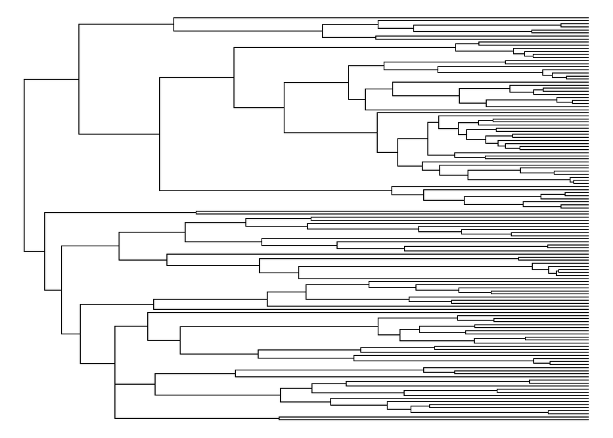

```r
#name.check(ftree, alldat)
#length(intersect(alldat$Species, rownames(alldat)))
drostree <- drop.tip(ftree, fchk$tree_not_data)
plotTree(drostree,ftype="off", cex=0.3,lwd=1)
```

I’ve elected to remove the tip labels from this tree in order to make it somewhat legible. I did this on purpose. That was a problem I had to solve on my own, the book did not guide me there.

Now let’s get the BM, EB, and OU for the genome size. I will again be using the female tree.

```r
#genome - our genome size subset of alldat
#Brown - our brownian motion for genomsize
#Early - our early bust for genome size
#Ough - Our OU that I'm totally forgetting what it stands for.

genome<-alldat[drostree$tip.label,"MbDNA_Female"]
genome
```

```
##   [1] 191.6 200.2 175.4 165.6 170.0 170.0 168.3 179.9 171.8 187.5 203.1 201.8
##  [13] 231.0 207.4 145.2 155.8 176.5 245.9 176.8 192.1 175.9 206.4 241.6 298.0
##  [25] 227.6 257.8 240.6 259.5 253.1 192.9 256.4 196.0 312.7 249.3 325.4 202.5
##  [37] 224.3 174.5 203.2 194.3 234.8 199.3 198.1 211.8 203.1 221.8 265.2 215.9
##  [49] 242.4 165.7 224.6 271.9 190.6 218.7 188.0 186.3 219.1 214.7 240.3 221.1
##  [61] 181.1 286.1 179.2 215.7 291.3 184.4 330.9 134.7 201.7 208.1 205.2 202.2
##  [73] 211.9 197.1 180.8 188.4 210.6 254.4 252.1 256.7 248.6 256.8 211.5 297.4
##  [85] 279.2 262.2 289.6 245.0 219.7 273.2 226.0 224.8 249.1 244.1 226.7 238.3
##  [97] 200.0 215.3 223.0 219.0 168.6 201.8 184.2 181.9 180.6 165.0 164.9 208.3
## [109] 168.9 174.5 237.8 239.2 245.5 229.6 210.8 274.0 218.5 266.3 221.8 213.0
## [121] 223.6 241.0 198.2 205.1 218.4 219.0 244.7 264.5 211.8 215.1 211.5 251.6
```

```r
names(genome)<-drostree$tip.label

brown<-fitContinuous(drostree, genome)
brown
```

```
## GEIGER-fitted comparative model of continuous data
##  fitted 'BM' model parameters:
##  sigsq = 59.605280
##  z0 = 211.783954
##
##  model summary:
##  log-likelihood = -651.537135
##  AIC = 1307.074270
##  AICc = 1307.167294
##  free parameters = 2
##
## Convergence diagnostics:
##  optimization iterations = 100
##  failed iterations = 0
##  number of iterations with same best fit = 100
##  frequency of best fit = 1.000
##
##  object summary:
##  'lik' -- likelihood function
##  'bnd' -- bounds for likelihood search
##  'res' -- optimization iteration summary
##  'opt' -- maximum likelihood parameter estimates
```

```r
#early<-fitContinuous(drostree, genome, model="EB",bounds=list(a=c(-10, -1e-6)))
#early
#So it turns out that the EB is not going to work for me.The data doens't support it and I can't figure out how to force it.
#SO I'll just compare brown and ough together.
ough<-fitContinuous(drostree, genome,model="OU")
ough
```

```
## GEIGER-fitted comparative model of continuous data
##  fitted 'OU' model parameters:
##  alpha = 0.031884
##  sigsq = 99.508854
##  z0 = 214.314569
##
##  model summary:
##  log-likelihood = -645.266743
##  AIC = 1296.533485
##  AICc = 1296.720985
##  free parameters = 3
##
## Convergence diagnostics:
##  optimization iterations = 100
##  failed iterations = 0
##  number of iterations with same best fit = 25
##  frequency of best fit = 0.250
##
##  object summary:
##  'lik' -- likelihood function
##  'bnd' -- bounds for likelihood search
##  'res' -- optimization iteration summary
##  'opt' -- maximum likelihood parameter estimates
```

```r
compare<-setNames(c(AIC(brown),AIC(ough)),c("BM","OU"))
compare
```

```
##       BM       OU
## 1307.074 1296.533
```

####Final Words#### I’ll be fully honest, I kind of regret choosing this project. I should’ve just done something simpler. But you saw my Withered Foxy gif, simple doesn’t always vibe with me.

I apologize if this isn’t exactly what you’d want from this assignment. This is what I’ve done, and this semester has been such a nightmare for me that this is all I can do.

I’ll be continuing to go through this book over the summer, probably at a slower pace though. I know I’m pretty new to this, but I look forward to my career as a bioinformatician. Thank you for your patience with me.

I learned a lot from this project and will hopefully learn even more from the book over the summer. I hope you have a nice summer as well. Thank you for your time.

-Beth Larsen.